# Assignment 3 - CRD

Author

Pramod Hegde

# Introduction

This assignment will ask you to conduct a full CRD analysis, from data import through publication ready plot.

The different sections representing what we did in class were left in the script to provide you a scaffold to start from.

# Instructions

- Move this script into the `code` subfolder of your `03_crd` project folder
- Move the file `wheat_nk_bamyan.csv` into the `data` folder of your `03_crd` project folder
- On this script, fill your name under the `title` section of the YAML

# a) Setup

Here is where we load the packages we will use.  
Make sure to load each package in the chunk below.

```r
library(tidyverse)
library(car)
library(broom)
library(emmeans)
library(multcomp)
library(multcompView)
```

Now, import the data set `wheat_nk_bamyan.csv` in the chunk below.

```r
df <- read.csv("../Data/wheat_nk_bamyan.csv")
```

The **objective of this study** was to assess the effect of different N and K rates on wheat yield.

For that, a study was conducted using a completely randomized design as the experimental design with four replicates. The treatment design was a 3 N x 3 K rate factorial, for a total of 9 treatments.

# b) EDA tables

Use this space to conduct exploratory data analysis of the imported data, in the form of tables.

```r
summary(df)
```

```
      trt         rep         nrate_kgha    krate_kgha   yield_kgha
 Min.   :1   Min.   :1.00   Min.   :  0   Min.   : 0   Min.   : 812
 1st Qu.:3   1st Qu.:1.75   1st Qu.:  0   1st Qu.: 0   1st Qu.:2630
 Median :5   Median :2.50   Median :100   Median :30   Median :3750
 Mean   :5   Mean   :2.50   Mean   :100   Mean   :30   Mean   :3838
 3rd Qu.:7   3rd Qu.:3.25   3rd Qu.:200   3rd Qu.:60   3rd Qu.:5238
 Max.   :9   Max.   :4.00   Max.   :200   Max.   :60   Max.   :7232
```

```r
glimpse(df)
```

```
Rows: 36
Columns: 5
$ trt        <int> 1, 2, 3, 4, 5, 6, 7, 8, 9, 1, 2, 3, 4, 5, 6, 7, 8, 9, 1, 2,…
$ rep        <int> 1, 1, 1, 1, 1, 1, 1, 1, 1, 2, 2, 2, 2, 2, 2, 2, 2, 2, 3, 3,…
$ nrate_kgha <int> 0, 0, 0, 100, 100, 100, 200, 200, 200, 0, 0, 0, 100, 100, 1…
$ krate_kgha <int> 0, 30, 60, 0, 30, 60, 0, 30, 60, 0, 30, 60, 0, 30, 60, 0, 3…
$ yield_kgha <int> 1350, 2110, 5725, 2988, 3438, 6525, 2825, 4400, 7025, 2250,…
```

# c) Wrangling

```r
wrangled <- df %>%
  mutate(rep = factor(rep),
         nrate_kgha = factor(nrate_kgha),
         krate_kgha = factor(krate_kgha),
         trtname = paste0(nrate_kgha, "+", krate_kgha), .before = yield_kgha
         )

glimpse(wrangled)
```

```
Rows: 36
Columns: 6
$ trt        <int> 1, 2, 3, 4, 5, 6, 7, 8, 9, 1, 2, 3, 4, 5, 6, 7, 8, 9, 1, 2,…
$ rep        <fct> 1, 1, 1, 1, 1, 1, 1, 1, 1, 2, 2, 2, 2, 2, 2, 2, 2, 2, 3, 3,…
$ nrate_kgha <fct> 0, 0, 0, 100, 100, 100, 200, 200, 200, 0, 0, 0, 100, 100, 1…
$ krate_kgha <fct> 0, 30, 60, 0, 30, 60, 0, 30, 60, 0, 30, 60, 0, 30, 60, 0, 3…
$ trtname    <chr> "0+0", "0+30", "0+60", "100+0", "100+30", "100+60", "200+0"…
$ yield_kgha <int> 1350, 2110, 5725, 2988, 3438, 6525, 2825, 4400, 7025, 2250,…
```

# d) EDA plots

Now, explore the wrangled data using plots.  
Make sure to explore plots showing the main effects and the interaction.

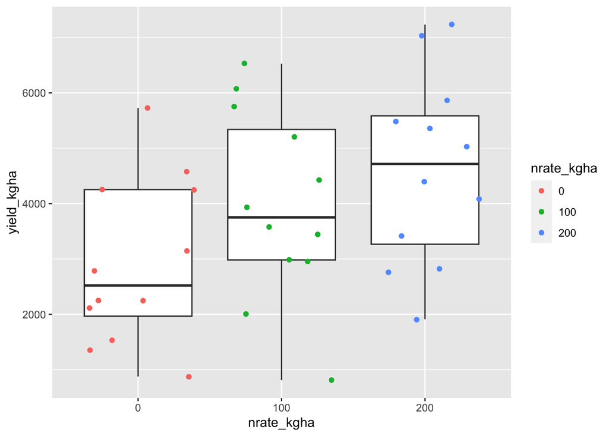

```r
wrangled %>%
  ggplot(aes(nrate_kgha, yield_kgha))+
  geom_boxplot()+
  geom_jitter(aes(color = nrate_kgha))
```

Nothing too discernible in the figure, except for the fact that the yield seems to be increasing with increasing N rates.

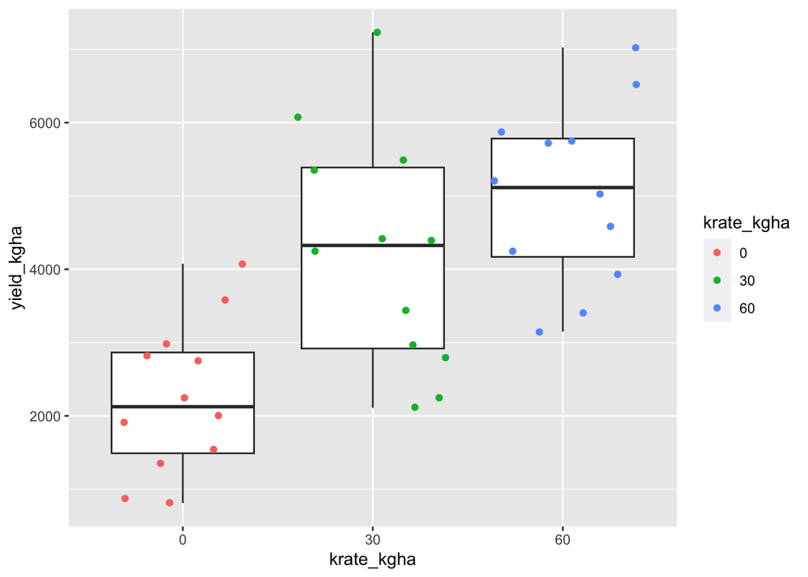

```r
wrangled %>%
  ggplot(aes(krate_kgha,yield_kgha))+
  geom_boxplot()+
  geom_jitter(aes(color = krate_kgha))
```

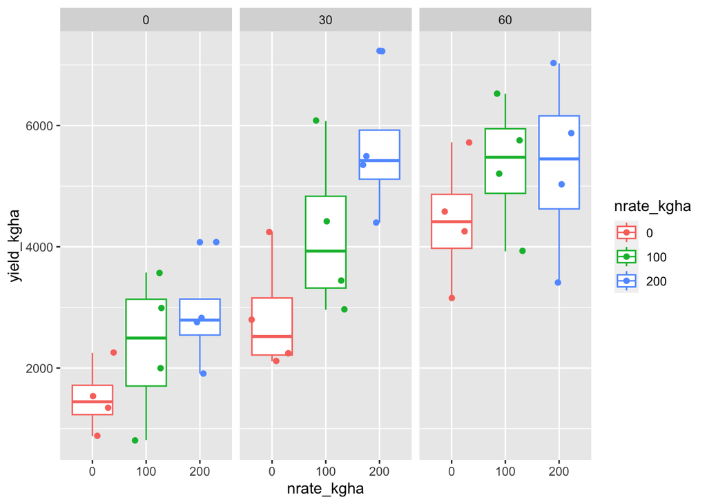

```r
wrangled %>%
  ggplot(aes(nrate_kgha,yield_kgha,
             color = nrate_kgha))+
  geom_boxplot()+
  geom_jitter()+
  facet_grid(.~krate_kgha)
```

The first two grids i.e treatments with 0,30 kg of K, have a linear increase in their mean yield with increasing N rates, but the third grid with K treatment of 60 kg/ha, there is a strong jump in yield values with N treatment of 100 kg/ha almost in par with the 200 N kg/ha treatment, implying some interaction effects.

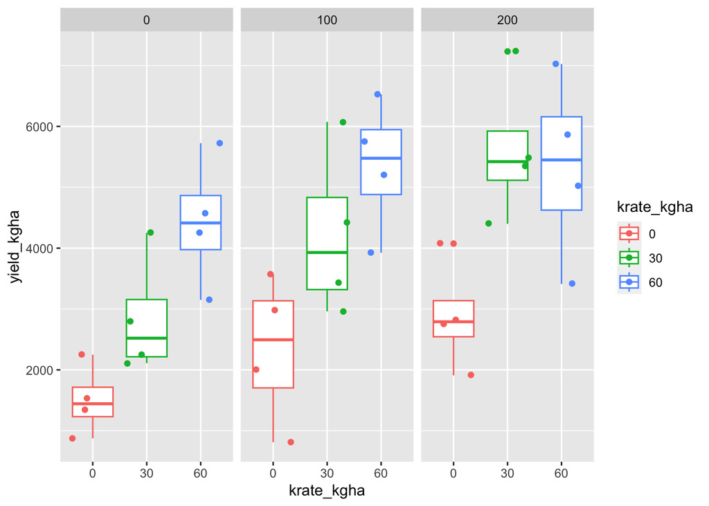

```r
wrangled %>%
  ggplot(aes(krate_kgha,yield_kgha,
             color = krate_kgha))+
  geom_boxplot()+
  geom_jitter()+
  facet_grid(.~nrate_kgha)
```

There seems to be no interaction effects in N rates of 0 and 100, but we can see some effects when N rate is 200. The yield values for the treatment with 200kg of N and 30kg of K has a higher yield than similar K treatements but with different N rates. The first two grids follow an increasing pattern as K rate increases, which is absent in the third grid signifying interaction effects.

## Question 1) Below each plot of this section, write a sentence explaining your visual interpretation of the plot.

# e) Statistical model

In this section, run the appropriate model.  
Remember to set the contrast type to sum-to-zero (the default in R is set-to-zero, which is not what we want).

Also, remember to specify all model terms needed for the treatment design.

```r
options(contrasts = c("contr.sum", "contr.poly"))

mod <- lm(yield_kgha ~ nrate_kgha + krate_kgha + nrate_kgha:krate_kgha,
              data = wrangled
              )
summary(mod)
```

```
Call:
lm(formula = yield_kgha ~ nrate_kgha + krate_kgha + nrate_kgha:krate_kgha,
    data = wrangled)

Residuals:
    Min      1Q  Median      3Q     Max
-1922.0  -656.1  -133.0   669.8  1851.5

Coefficients:
                        Estimate Std. Error t value Pr(>|t|)
(Intercept)              3837.94     188.07  20.407  < 2e-16 ***
nrate_kgha1              -911.61     265.97  -3.427  0.00197 **
nrate_kgha2               134.89     265.97   0.507  0.61616
krate_kgha1             -1591.78     265.97  -5.985  2.2e-06 ***
krate_kgha2               392.81     265.97   1.477  0.15128
nrate_kgha1:krate_kgha1   168.44     376.14   0.448  0.65785
nrate_kgha2:krate_kgha1   -37.06     376.14  -0.099  0.92225
nrate_kgha1:krate_kgha2  -468.89     376.14  -1.247  0.22326
nrate_kgha2:krate_kgha2  -142.14     376.14  -0.378  0.70847
---
Signif. codes:  0 '***' 0.001 '**' 0.01 '*' 0.05 '.' 0.1 ' ' 1

Residual standard error: 1128 on 27 degrees of freedom
Multiple R-squared:  0.6737,    Adjusted R-squared:  0.577
F-statistic: 6.969 on 8 and 27 DF,  p-value: 5.675e-05
```

# f) ANOVA table

Use this section to check the ANOVA table, ensuring you use type 3 sum-of-squares.

```r
Anova(mod, type = 3)
```

```
Anova Table (Type III tests)

Response: yield_kgha
                         Sum Sq Df  F value    Pr(>F)
(Intercept)           530273432  1 416.4464 < 2.2e-16 ***
nrate_kgha             17430327  2   6.8444   0.00394 **
krate_kgha             49507045  2  19.4400 5.892e-06 ***
nrate_kgha:krate_kgha   4051423  4   0.7954   0.53857
Residuals              34379890 27
---
Signif. codes:  0 '***' 0.001 '**' 0.01 '*' 0.05 '.' 0.1 ' ' 1
```

## Question 2) Based on the ANOVA table above, for which effect(s) in the ANOVA should you extract means and perform pair-wise comparisons? Explain why.

Based on the ANOVA table, there is no significant interaction effects and hence we proceed to testing the effects of individual treatments which are both significant.

# g) Linear model assumptions

Use this section to first compute your residuals, including studentdized residuals.

## Question 3) What are the linear model assumptions that we need to check for? Create subsections (using ##) below for each of these assumptions, and write code to produce plots to check for these assumptions. For each assumption, write down your interpretation of the produced plots, and your thoughts if the assumptions hold or not.

## Extracting residuals

```r
resid <- augment(mod) %>%
  mutate(.studresid = rstudent(mod))
resid
```

```
# A tibble: 36 × 10
   yield_kgha nrate_kgha krate_kgha .fitted  .resid  .hat .sigma  .cooksd
        <int> <fct>      <fct>        <dbl>   <dbl> <dbl>  <dbl>    <dbl>
 1       1350 0          0            1503.  -153.  0.25   1149. 0.000908
 2       2110 0          30           2850.  -740.  0.25   1138. 0.0213
 3       5725 0          60           4426.  1299.  0.250  1112. 0.0655
 4       2988 100        0            2344.   644.  0.25   1141. 0.0161
 5       3438 100        30           4224.  -786.  0.25   1136. 0.0239
 6       6525 100        60           5351   1174   0.25   1119. 0.0535
 7       2825 200        0            2891.   -66.5 0.25   1150. 0.000172
 8       4400 200        30           5618. -1218.  0.25   1116. 0.0576
 9       7025 200        60           5334   1691   0.25   1084. 0.111
10       2250 0          0            1503.   747.  0.25   1137. 0.0216
# ℹ 26 more rows
# ℹ 2 more variables: .std.resid <dbl>, .studresid <dbl>
```

The columns “.std.resid” and “.studresid” are the studentized residuals. The two are the same but calculated by different packages (slightly different methods).

## Model assumption 1 - Residual independence

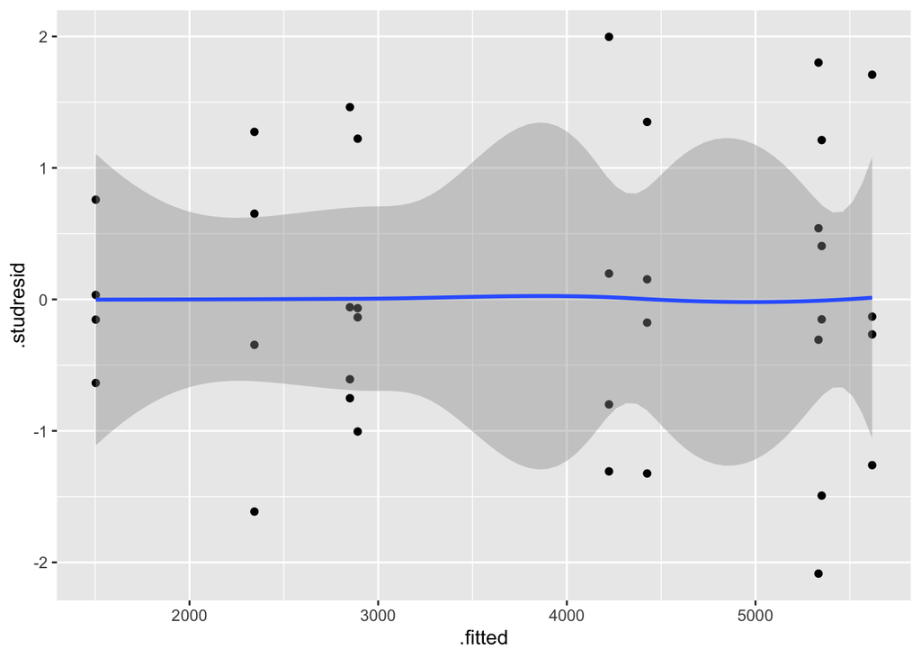

```r
resid %>%
  ggplot(aes(.fitted,.studresid))+
  geom_point()+
  geom_smooth()
```

There does not seem to be any definite pattern in the residuals, satisfying the first model assumption of residual independennce.

## Model assumption 2 - Residual homoscedascity

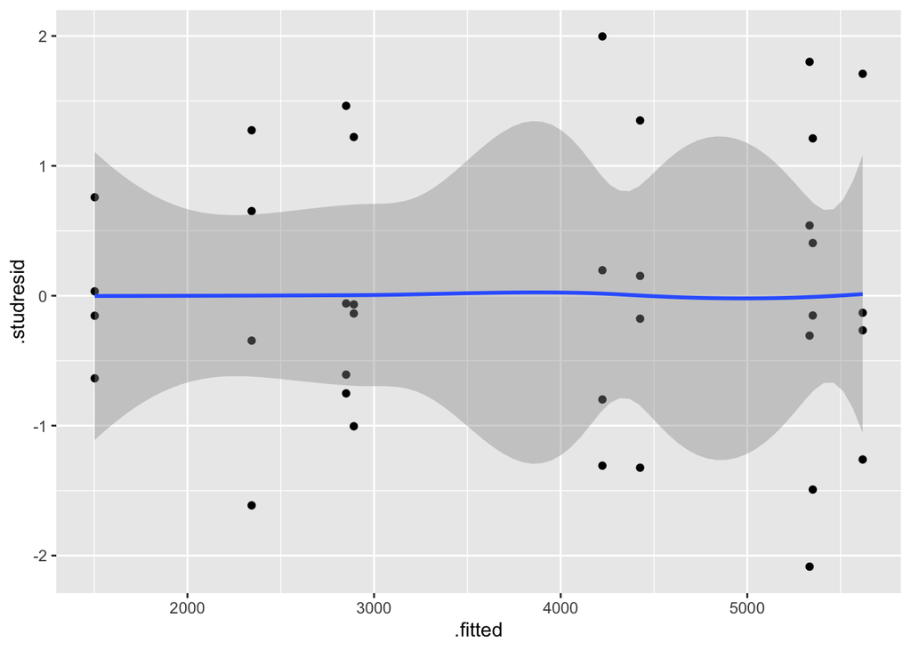

```r
resid %>%
  ggplot(aes(.fitted, .studresid))+
  geom_point()+
  geom_smooth()
```

We see no fan shaped curve, therefore satisfying the model assumption of homescedascity.

## Model assumption 3 - Residual normality

We expect to see a normal distribution of the residuals centered around 0. Quantile - quantile plot will help us check this assumption

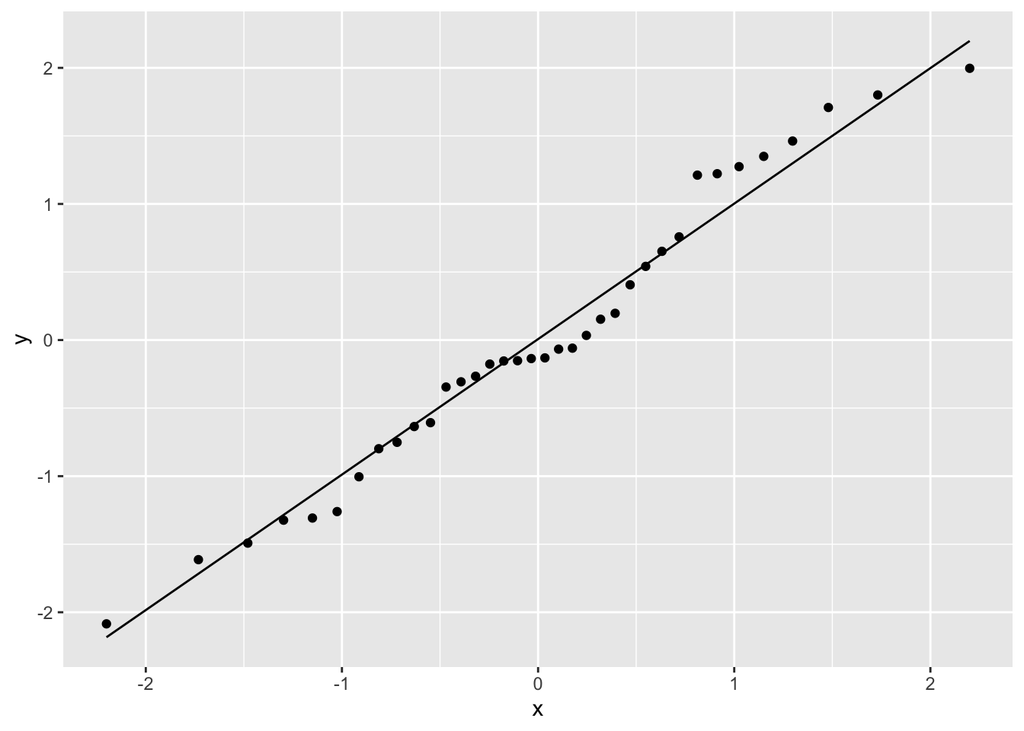

```r
resid %>%
  ggplot(aes(sample = .studresid))+
  stat_qq()+
  stat_qq_line()
```

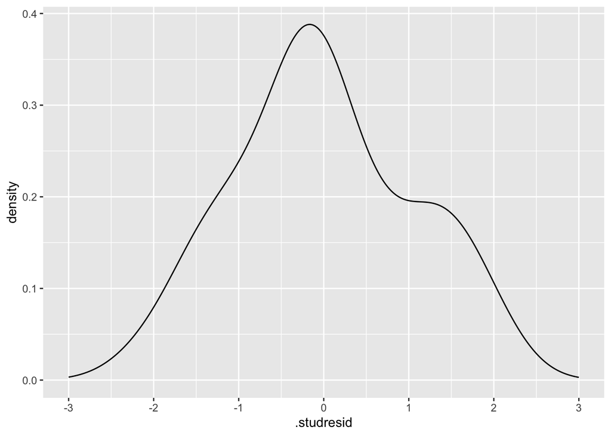

```r
resid %>%
  ggplot(aes(.studresid))+
  geom_density()+
  scale_x_continuous(limits = c(-3,3), breaks = c(-3:3))
```

From the above two graphs, we can say that the residuals are normally distributed around mean 0.

## Model assumption 4 - Residual outliers

Residuals as far as possible should stay within the limits of +- 3 standard deviations from the mean. A fitted vs residuals curve will help us interpret for any outliers.

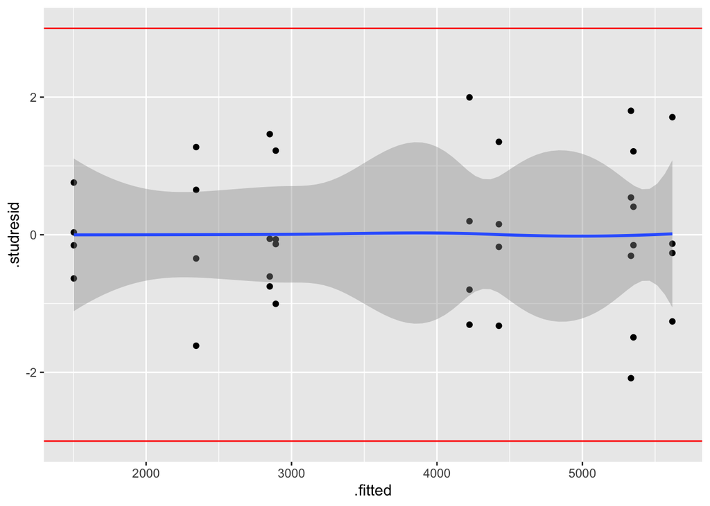

```r
resid %>%
  ggplot(aes(.fitted , .studresid))+
  geom_point()+
  geom_smooth()+
  geom_hline(yintercept = c(-3,3), color = "red")
```

None of the residuals are beyond the threshold of 3 SDs, and hence this model assumption is proved. Now that all assumptions have been proved, we can move ahead to using the model for inference.

# h) Model means

Use this section to extract model means according to your decision of the ANOVA table effects.

From the anova table, we have seen that interaction effects have not been significant, but we will extract means for this.

```r
means_all <- emmeans(mod,
                ~nrate_kgha * krate_kgha)
means_all
```

```
 nrate_kgha krate_kgha emmean  SE df lower.CL upper.CL
 0          0            1503 564 27      345     2661
 100        0            2344 564 27     1186     3502
 200        0            2892 564 27     1734     4049
 0          30           2850 564 27     1693     4008
 100        30           4224 564 27     3066     5381
 200        30           5618 564 27     4461     6776
 0          60           4426 564 27     3268     5583
 100        60           5351 564 27     4193     6509
 200        60           5334 564 27     4176     6492

Confidence level used: 0.95
```

This was not really needed because we did not find any interaction in the anova table.

The following chunk calculates the mean only for N rate.

```r
means_n <- emmeans(mod, ~ nrate_kgha)
```

```
NOTE: Results may be misleading due to involvement in interactions
```

```r
means_n
```

```
 nrate_kgha emmean  SE df lower.CL upper.CL
 0            2926 326 27     2258     3595
 100          3973 326 27     3304     4641
 200          4615 326 27     3946     5283

Results are averaged over the levels of: krate_kgha
Confidence level used: 0.95
```

```r
means_k <- emmeans(mod, ~krate_kgha)
```

```
NOTE: Results may be misleading due to involvement in interactions
```

```r
means_k
```

```
 krate_kgha emmean  SE df lower.CL upper.CL
 0            2246 326 27     1578     2915
 30           4231 326 27     3562     4899
 60           5037 326 27     4369     5705

Results are averaged over the levels of: nrate_kgha
Confidence level used: 0.95
```

# i) Pairwise comparisons

Use this section to perform pair-wise comparison of the means extracted above.

Make sure to reverse the order from high to low, use letters instead of numbers, and no adjustment.

```r
cld_n <- cld(means_n,
              reversed = T,
              Letters = letters,
              adjust = "none")
cld_n
```

```
 nrate_kgha emmean  SE df lower.CL upper.CL .group
 200          4615 326 27     3946     5283  a
 100          3973 326 27     3304     4641  a
 0            2926 326 27     2258     3595   b

Results are averaged over the levels of: krate_kgha
Confidence level used: 0.95
significance level used: alpha = 0.05
NOTE: If two or more means share the same grouping symbol,
      then we cannot show them to be different.
      But we also did not show them to be the same.
```

```r
cld_k <- cld(means_k,
              reversed = T,
              Letters = letters,
              adjust = "none")
cld_k
```

```
 krate_kgha emmean  SE df lower.CL upper.CL .group
 60           5037 326 27     4369     5705  a
 30           4231 326 27     3562     4899  a
 0            2246 326 27     1578     2915   b

Results are averaged over the levels of: nrate_kgha
Confidence level used: 0.95
significance level used: alpha = 0.05
NOTE: If two or more means share the same grouping symbol,
      then we cannot show them to be different.
      But we also did not show them to be the same.
```

```r
cld_n_converted <- cld_n %>%
  as.data.frame() %>%
  mutate(letter = trimws(.group))
cld_n_converted
```

```
  nrate_kgha   emmean       SE df lower.CL upper.CL .group letter
1        200 4614.667 325.7465 27 3946.290 5283.043     a       a
2        100 3972.833 325.7465 27 3304.457 4641.210     a       a
3          0 2926.333 325.7465 27 2257.957 3594.710      b      b
```

```r
cld_k_converted <- cld_k %>%
  as.data.frame() %>%
  mutate(letter = trimws(.group))
cld_k_converted
```

```
  krate_kgha   emmean       SE df lower.CL upper.CL .group letter
1         60 5036.917 325.7465 27 4368.540 5705.293     a       a
2         30 4230.750 325.7465 27 3562.373 4899.127     a       a
3          0 2246.167 325.7465 27 1577.790 2914.543      b      b
```

# g) Final plot(s)

Produce final plot(s) to show your results.  
Make sure to include both **raw data** and **statistical model summary (i.e., letter separation)**.

Be mindful of your plot to ensure you are creating it in an intuitive way for your audience in relation to interpreting the letter separation structure you used.

In class, we did not have time to make it publication-ready (e.g., a plot looking professional and ready to be included in a manuscript).

Here, make sure you deliver final plot(s) that is/are publication ready.

Make sure to provide an interpretation for the plot(s) created, including which treatment levels were significantly higher/lower.

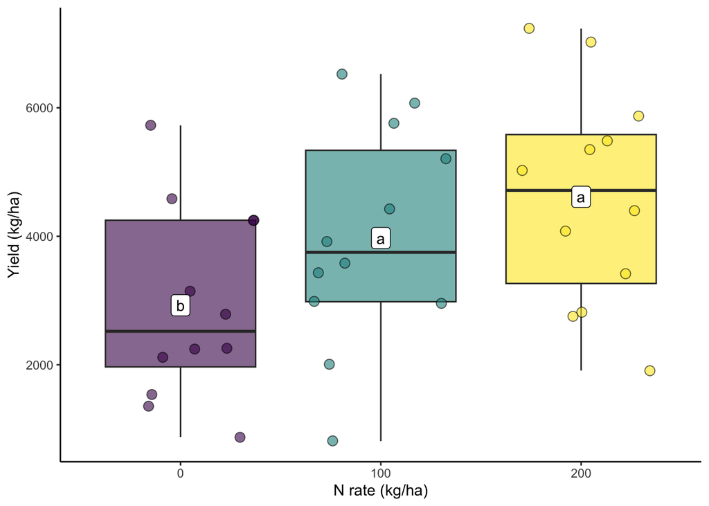

```r
ggplot(mapping = aes(fill = nrate_kgha)) +
  geom_boxplot(data = wrangled,
               aes(nrate_kgha, yield_kgha, fill = nrate_kgha),
               alpha = 0.6
               ) +
  geom_jitter(data = wrangled,
              aes(nrate_kgha, yield_kgha),
              shape = 21,
              alpha = 0.6,
              size = 3)+
  geom_label(data = cld_n_converted,
             aes(nrate_kgha, emmean, label = letter),
             fill = "white"
             )+
  labs(x = "N rate (kg/ha)",
       y = "Yield (kg/ha)")+
  theme_classic()+
  theme(legend.position = "none")+
  scale_fill_viridis_d()
```

From the above graph, we can say that N rate of 0 kg/ha had significantly lower yield. Although the treatments of 100 and 200 kg/ha have slightly different yield values(visually), they are not statistically different.

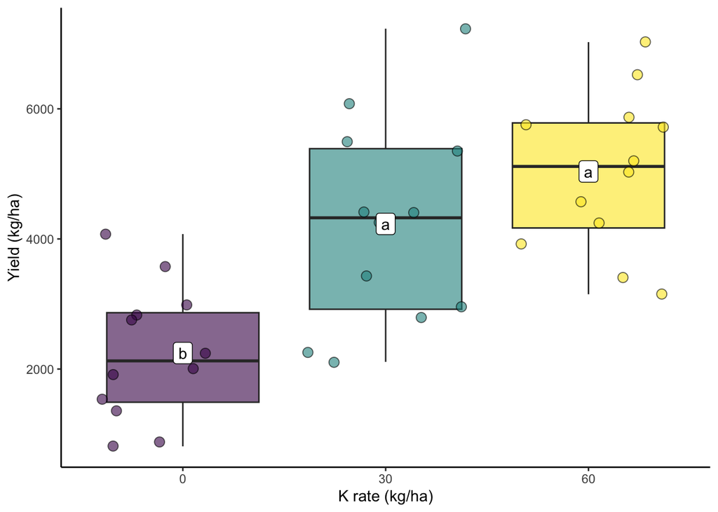

```r
ggplot(mapping = aes(fill = krate_kgha))+
  geom_boxplot(data = wrangled,
               aes(krate_kgha, yield_kgha, fill = krate_kgha),
               alpha = 0.6
               )+
  geom_jitter(data = wrangled,
              aes(krate_kgha, yield_kgha),
              shape = 21,
              alpha = 0.6,
              size = 3)+
  geom_label(data = cld_k_converted,
             aes(krate_kgha, emmean, label = letter),
             fill = "white"
             )+
  labs(x = "K rate (kg/ha)",
       y = "Yield (kg/ha)")+
  scale_fill_viridis_d()+
  theme_classic()+
  theme(legend.position = "none")
```

K rate of 0 kg/ha has a significantly lower yield as compared to the other two treatments.

# Submitting your work

Once you have developed all the code and answers, make sure to Render this quarto file.

**Notes on rendering**:

- Make sure to render your work and inspect how the final html look like.
- If it does not look professional for whatever reason, then fix the issue, re-render it, recheck.
- Only send me your work once your html file looks professional.
  - **DO NOT** delete the file’s heading levels (# and ##). They set up the proper heading 1 and 2 levels, and I use them to guide my grading.
  - If a given chunk is also outputting warnings or messages, inhibit this behavior by changing the chunk options `message` and `warning` to `FALSE` (I’ll demo this in a moment).
  - If, after rendered, 2 lines of text are connected and you wish to “break line” between them, add 2 extra spaces after the first one (I’lld demo this in a moment).

After rendering, an .html file will be created on your `code` folder.

Rename this file to `Assignment-03-crd-LASTNAME.html`.

For ex., mine would be `Assignment-03-crd-Bastos.html`.

Send the **html** file to **lmbastos@uga.edu** by Feb 15th 11:59 pm.